# Energy Predictor

Team 3

4/22/2020

## Competition/Project Objective

The purpose of this competition/objective is to develop accurate models of metered building energy usage in the following areas: chilled water, electric, hot water, and steam meters.

### How We Arrive At Our Model:

We begin with taking into consideration the background of the competition and make note of any assumptions we might have regarding the project itself or the datasets provided.

Then we take the following steps to write our notebook and ultimately complete our project:

#### 1) Load Data

#### 2) Preprocessing

#### 3) EDA

#### 4) Build And Train Model

#### 5) Outcome Evaluation

## Load Data Into R

```r
dpath <- "./"
train <- read.csv(paste(dpath, "train.csv", sep=""),row.names = NULL)
building<-read.csv('building_metadata.csv',row.names = NULL)
weather_train<-read.csv('weather_train.csv',row.names = NULL)
```

## Preprocessing

### Joining The Data Tables

Utilizing a left join to merge the building metadata set and weather train set with the train set.

```r
train<-train%>%
  left_join(building,by='building_id')%>%
  left_join(weather_train,by=c('site_id',"timestamp"))
```

#### Take A Glimpse Of The Data Structure

```r
head(train,5)
```

```
##   building_id meter           timestamp meter_reading site_id primary_use
## 1           0     0 2016-01-01 00:00:00             0       0   Education
## 2           1     0 2016-01-01 00:00:00             0       0   Education
## 3           2     0 2016-01-01 00:00:00             0       0   Education
## 4           3     0 2016-01-01 00:00:00             0       0   Education
## 5           4     0 2016-01-01 00:00:00             0       0   Education
##   square_feet year_built floor_count air_temperature cloud_coverage
## 1        7432       2008          NA              25              6
## 2        2720       2004          NA              25              6
## 3        5376       1991          NA              25              6
## 4       23685       2002          NA              25              6
## 5      116607       1975          NA              25              6
##   dew_temperature precip_depth_1_hr sea_level_pressure wind_direction
## 1              20                NA             1019.7              0
## 2              20                NA             1019.7              0
## 3              20                NA             1019.7              0
## 4              20                NA             1019.7              0
## 5              20                NA             1019.7              0
##   wind_speed
## 1          0
## 2          0
## 3          0
## 4          0
## 5          0
```

### Creating New Variables

In this instance, we are creating three new variables and tranforming another.

```r
#Transform the data to days in a week(1,2,3,4,5,6,7)
train$wday=wday(train$timestamp)
#Identify whether it's workday or not
train$workday=ifelse(train$wday %in% c(1,2,3,4,5),1,0)
#Take out the month information
train$month=month(train$timestamp)
#Normalize the target so that it's not scaled
train$meter_reading=log1p(train$meter_reading)
```

### Feature Selection

```r
#Select columns as input variables
names_selected=c("building_id","site_id","meter","primary_use","square_feet","air_temperature","cloud_coverage","wind_direction","wind_speed", "month","workday","meter_reading")
#Get the new dataset
train.new=train[names_selected]
```

### Converting Categorical Variable To Numeric

```r
#Transfrom "primary_use" variable to numerirical data
train.new$primary_use=as.integer(as.factor(train.new$primary_use))
```

### Fill In Missing/Null Data

Because the missing data portion is small, we could just use the average to replace the NAs.

```r
#Deal with air temperature missing data
train.new$air_temperature[is.na(train.new$air_temperature)] <- mean(train.new$air_temperature, na.rm = TRUE)
#Deal with cloud coverage mmissing data
train.new$cloud_coverage[is.na(train.new$cloud_coverage)] <- mean(train.new$cloud_coverage, na.rm = TRUE)
#Deal with wind direction missing data
train.new$wind_direction[is.na(train.new$wind_direction)] <- mean(train.new$wind_direction, na.rm = TRUE)
```

## Exploratory Discriminant Analysis

### Correlation Plot

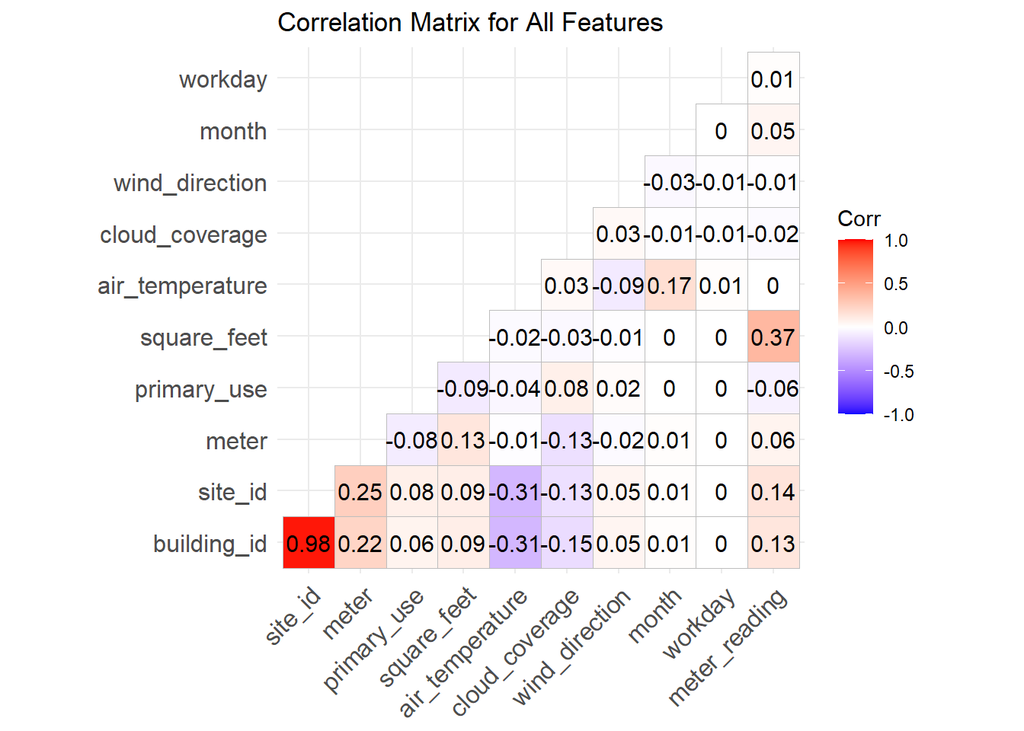

```r
ggcorrplot(cor(train.new), type = "lower", lab = TRUE,
           title = "Correlation Matrix for All Features")
```

### Evaluate Multicollinearity Between Predictor Variables

```
##     building_id           meter     primary_use     square_feet air_temperature
##        4.378302        1.071305        4.193140        1.031474        1.113741
##  cloud_coverage  wind_direction      wind_speed           month         workday
##        1.042030        1.011486        1.148095        1.137977        1.008817
```

The VIFs of the predictors are all relatively low, with building_id and primary_use being the only noteworthy variables. Multicollinearity does not appear to be a huge concern going forward for the majority of our variables.

## Build And Train Model

### XGBoost Model

XGBoost is a ensemble method for machine learning which allows parrallel runnning. XGBoost is a powerful tool that has low bias. We selected XGBoost for our model because the size of our data, and the flexiblity XGBoost could achieve. For our problem, because the data is too large (378MB), and data from different sites may vary. We choose to train a seperate model on each site using XGBoost.

```r
#Extract data from site 1
train.new.site1=train.new[train.new$site_id==1,]
#Get number of rows for site 1
n=nrow(train.new.site1)
#Sample the data into training and test set
train.index=sample(seq(1,n),n*0.8,replace = F)
#Transfrom the training data into matrix before fitting into XGBoost model
xgb.data.train <- xgb.DMatrix(as.matrix(train.new.site1[train.index, colnames(train.new.site1) != 'meter_reading']), label = train.new.site1$meter_reading[train.index])
#Transfrom the test data into matrix before fitting into XGBoost model
xgb.data.test <- xgb.DMatrix(as.matrix(train.new.site1[-train.index, colnames(train.new) != "meter_readings"]), label = train.new.site1$meter_reading[-train.index])
```

### Parameter Tuning

We included 3 hyperparameters in the tuning process.

```r
# = eta candidates = #
eta=c(0.05,0.1,0.5)
# = max_depth candidates = #
md=c(6,10,12)
# = sub_sample candidates = #
ss=c(0.25,0.5,0.75,1)
```

### ETA

```r
#Define a vector to store rmse data
test_rmse=c()
#For each value of eta, the model will produce its test rmse over each round of training
for(i in 1:length(eta)){
  #Define parameters in the model
  params=list(booster = "gbtree",nthread = 4, objective = "reg:squarederror",
              eta = eta[i], gamma=0, max_depth=10, min_child_weight=1,
              subsample=1, colsample_bytree=0.85)
  #Using cross validation to find how the rmse changes over time
  xgbcv <- xgb.cv( params = params, data = xgb.data.train , nrounds = 500, nfold = 3, showsd = T, stratified = T, print_every_n = 100, maximize = F)
  #Get test rmse data
  test_rmse[i] = xgbcv$evaluation_log[,4]

}
```

```r
#Transfrom test_rmse of each value of eta into a dataframe
test_rmse = data.frame(iter=1:500,test_rmse)
#Name the test_rmse dataframe columns

colnames(test_rmse) =  c('iter',eta)
#Reshape the test_rmse for plotting
test_rmse = melt(test_rmse, id.vars = "iter")
```

Plot how each test rmse changes over training iterations

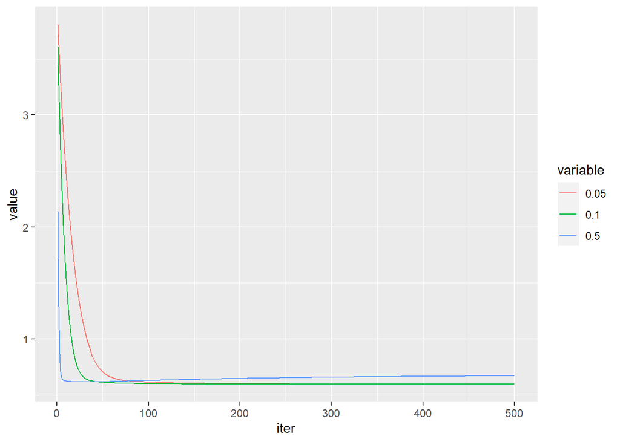

### Max Depth

```r
#Define a vector to store rmse data
test_rmse=c()
#For each value of max depth, the model will produce its test rmse over each round of training

for(i in 1:length(md)){
   #Define parameters in the model

  params=list(booster = "gbtree",nthread = 4, objective = "reg:squarederror",
              eta = 0.5, gamma=0, max_depth=md[i], min_child_weight=1,
              subsample=1, colsample_bytree=0.85)
  #Using cross validation to find how the rmse changes over time
  xgbcv <- xgb.cv( params = params, data = xgb.data.train , nrounds = 500, nfold = 3, showsd = T, stratified = T, print_every_n = 100, maximize = F)
  #Get test rmse data
  test_rmse[i] = xgbcv$evaluation_log[,4]

}
```

```r
#Transfrom test_rmse of each value of eta into a dataframe

test_rmse = data.frame(iter=1:500,test_rmse)
#Name the test_rmse dataframe columns

colnames(test_rmse) =  c('iter',md)
#Reshape the test_rmse for plotting

test_rmse = melt(test_rmse, id.vars = "iter")
```

Plot how each test rmse changes over training iterations

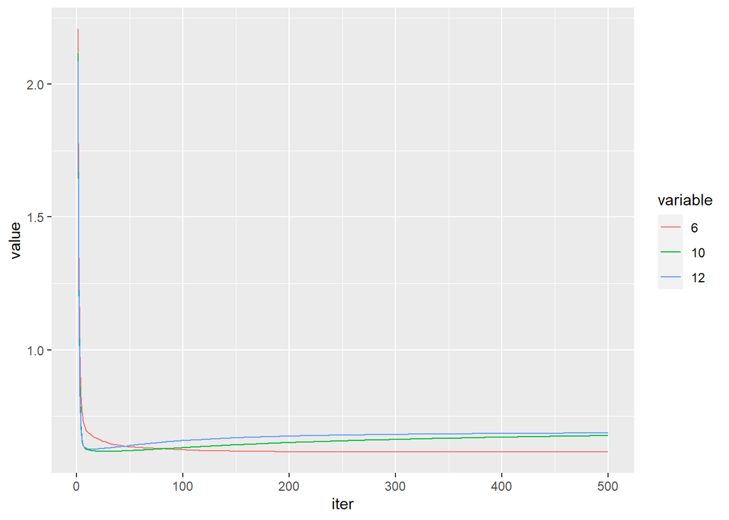

The best max depth 6.

### Subsample Candidates

```r
#Define a vector to store rmse data

test_rmse=c()
#For each value of subsample size, the model will produce its test rmse over each round of training

for(i in 1:length(ss)){
     #Define parameters in the model

  params=list(booster = "gbtree",nthread = 4, objective = "reg:squarederror",
              eta = 0.5, gamma=0, max_depth=6, min_child_weight=1,
              subsample=ss[i], colsample_bytree=0.85)
    #Using cross validation to find how the rmse changes over time

  xgbcv <- xgb.cv( params = params, data = xgb.data.train , nrounds = 500, nfold = 3, showsd = T, stratified = T, print_every_n = 100, maximize = F)
    #Get test rmse data

  test_rmse[i] = xgbcv$evaluation_log[,4]

}
```

```r
#Transfrom test_rmse of each value of subsample into a dataframe

test_rmse = data.frame(iter=1:500,test_rmse)
#Name the test_rmse dataframe columns

colnames(test_rmse) =  c('iter',ss)
#Reshape the test_rmse for plotting

test_rmse = melt(test_rmse, id.vars = "iter")
```

Plot how each test rmse changes over training iterations

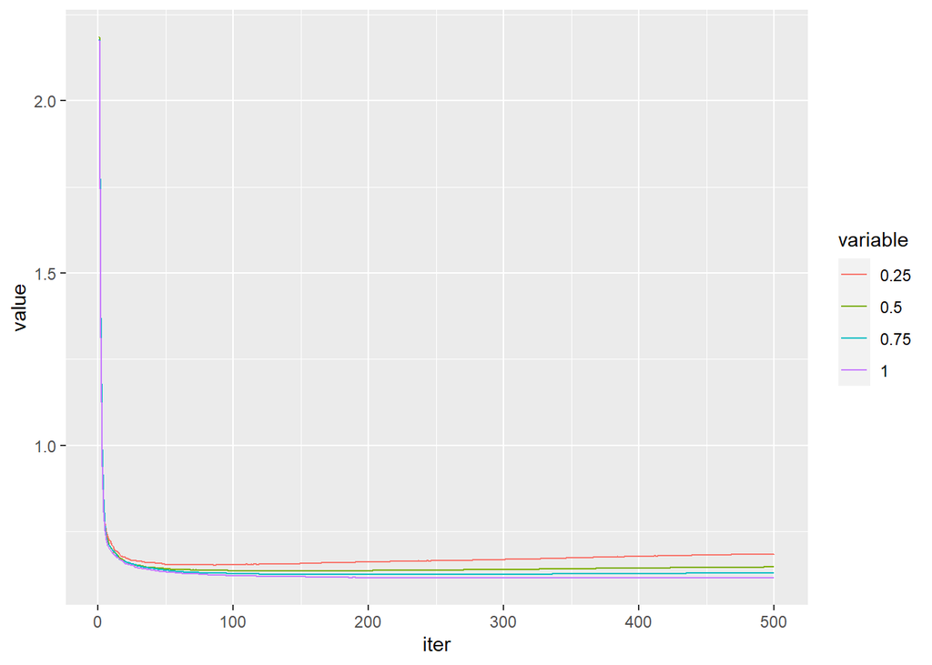

The best subsample size is 1.

### Fit Best Model

```r
#Define parameters using the best fit result above
params=list(booster = "gbtree",nthread = 4, objective = "reg:squarederror",
            eta = 0.5 , gamma=0, max_depth=6, min_child_weight=1,
            subsample=1, colsample_bytree=0.85)
#Train the data using hyperparameter values
xgb1 <- xgb.train (params = params, data = xgb.data.train, nrounds = 500, watchlist = list(val=xgb.data.test,train=xgb.data.train), print.every.n = 100,
                   early.stop.round = 10, maximize = F , eval_metric = "rmse")
```

```
## Multiple eval metrics are present. Will use train_rmse for early stopping.
## Will train until train_rmse hasn't improved in 10 rounds.
##
```

```r
#See how the model performs on the test data set
xgb1$evaluation_log[490:500]
```

```
##     iter val_rmse train_rmse
##  1:  490 0.599530   0.537899
##  2:  491 0.599507   0.537821
##  3:  492 0.599487   0.537695
##  4:  493 0.599439   0.537581
##  5:  494 0.599440   0.537546
##  6:  495 0.599386   0.537456
##  7:  496 0.599333   0.537392
##  8:  497 0.599224   0.537200
##  9:  498 0.599198   0.537121
## 10:  499 0.599219   0.537021
## 11:  500 0.599260   0.536889
```

## Outcome Evaluation: Feature Importance

```r
#Get the feature importance in the final model
mat <- xgb.importance (feature_names = colnames(train.new.site1),model = xgb1)
```

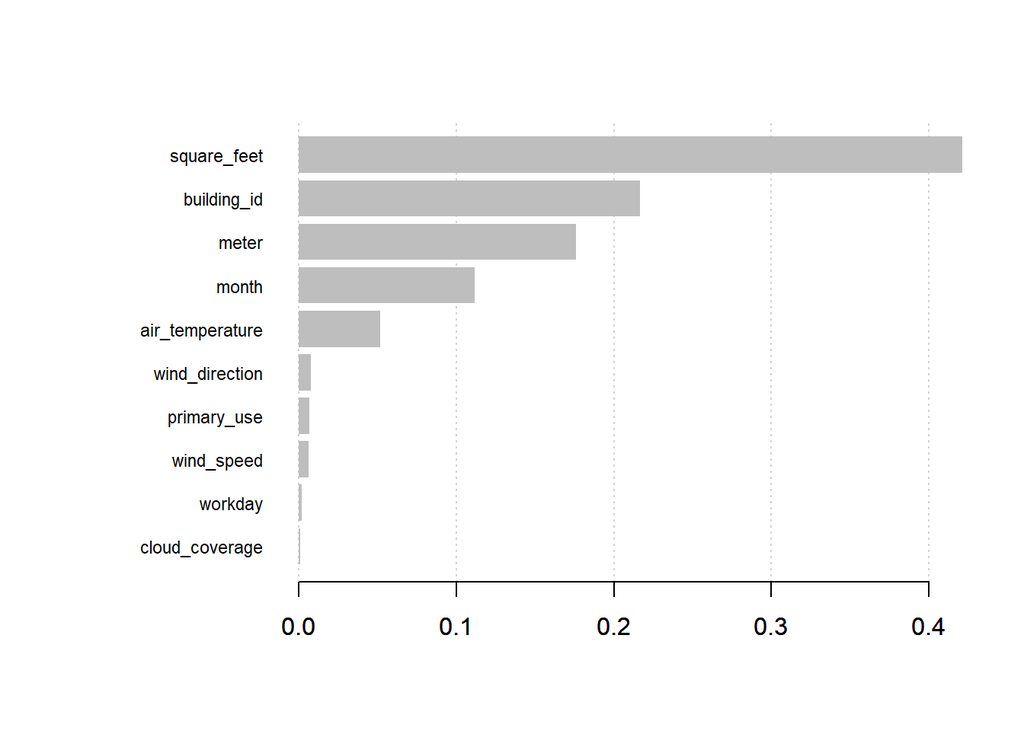

In the plot, we could see that the building_id, meter, and sqaure_feet are most important features in our model, which makes sense. Different buildings have different energy consumptions. Based on the type of meter, the energy consumption will vary. And bigger house with more square feet will use more energy.

Further we implemented our model in the test dataset on Kaggle which have no labels.